# An Analysis of the evolution of the Covid-19 pandemic

## Hospitalisation and Facilities

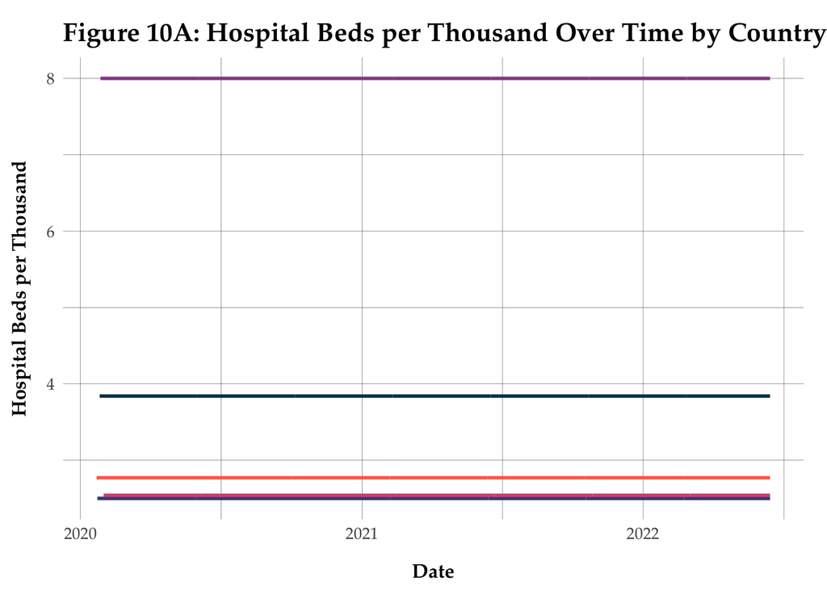

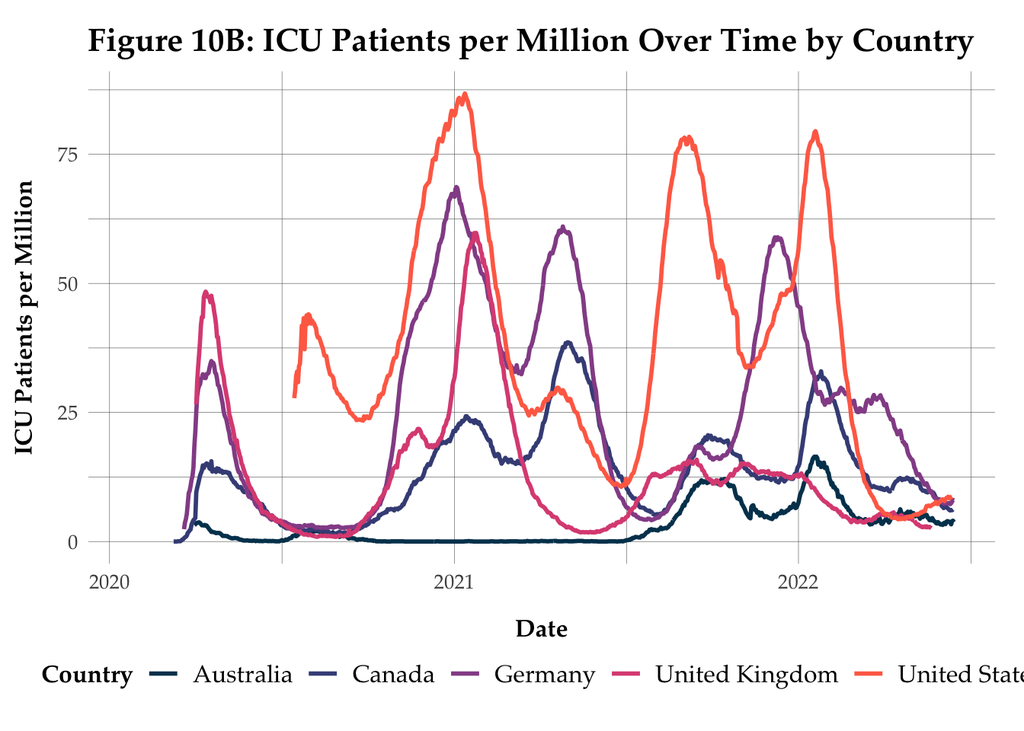

Figure 10 shows the evolution of number of hospital beds available and patients admitted to ICU. Unfortunately, the data on availability of hospital beds is very scarce and only some countries (typically richer) have data on this. Evidently, the data also does not reveal much in terms of how increases in hospitalisation facilities (hospital beds per thousand as a proxy) and ICU admissions are related.